# Case Study 01

As shown earlier, West Virginia and Delaware only have two beers in each state. There could be a good opportunity to sell beer here! We analyzed the most popular beers in states neighboring WV and DE. Based upon the statistics for the neighboring states, in Delaware, we think an American IPA with an IBU of 50-60 and an ABV of ~7%, an Imperial IPA with 80-90 IBU and ~8% ABV, or a Belgian Pale Ale with an IBU of ~20 and an ABV fo 7% would be successful here. In West Virginia, based upon the statistics in neighboring states, we think an American IPA of ~70 IBU and ABV of 6-7% or an APA with 45 IBU and an ABV 5-6% would be successful here.

```r
#Beers in DE: IPA and APA
brewByState %>% filter(State == " DE")
```

```
##   Brewery_id            BeerName Beer_ID   ABV IBU                   Style
## 1        317    Appreciation Ale    1784 0.065  69            American IPA
## 2        540 Greenville Pale Ale     433 0.055  52 American Pale Ale (APA)
##   Ounces                        Brewery       City State BeerClass
## 1     16 Iron Hill Brewery & Restaurant Wilmington    DE       IPA
## 2     12     Twin Lakes Brewing Company Greenville    DE       ALE
```

```r
#Beers in WV: Black Ale and APA
brewByState %>% filter(State == " WV")
```

```
##   Brewery_id            BeerName Beer_ID   ABV IBU                   Style
## 1        157 Wild Trail Pale Ale    2314 0.057  44 American Pale Ale (APA)
## 2        157   Mothman Black IPA    2313 0.067  71      American Black Ale
##   Ounces                           Brewery      City State BeerClass
## 1     12 Greenbrier Valley Brewing Company Lewisburg    WV       ALE
## 2     12 Greenbrier Valley Brewing Company Lewisburg    WV       ALE
```

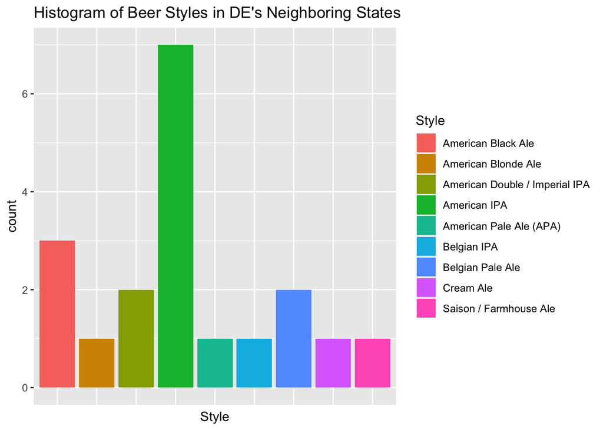

```r
#Create new data frame to hold the beers in states neighboring Delaware. Did not include Pennsylvania because it skewed this data.
beersDE <- brewByState %>% filter(State == " NJ" | State == " MD")
#Print histogram for styles of beer in Delaware's neighbor states.
beersDE %>% ggplot(aes(x = Style, fill = Style)) + geom_bar(stat = "count") + theme(axis.text.x=element_blank(),
        axis.ticks.x=element_blank())  + ggtitle("Histogram of Beer Styles in DE's Neighboring States")
```

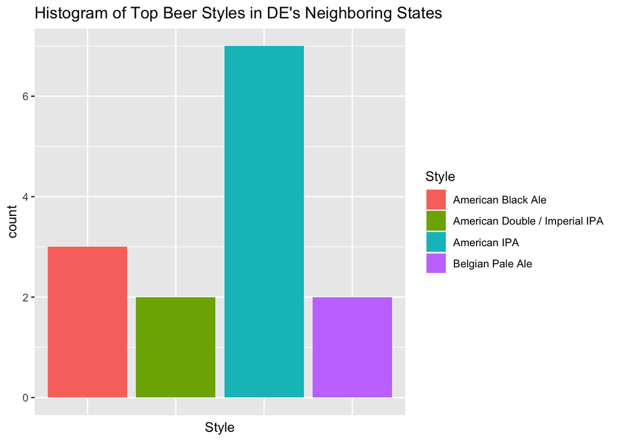

```r
#Top 4 beers near DE: IPAs, American Black Ale, American Double / Imperial IPA,  and Belgian Pale Ale
top4DE <- beersDE %>%  filter(Style =="American Double / Imperial IPA" | Style == "American IPA"|Style == "American Black Ale"|Style == "Belgian Pale Ale")
#Print histogram of the most popular beer styles near Delaware.
top4DE %>% ggplot(aes(x = Style, fill = Style)) + geom_bar(stat = "count") + theme(axis.text.x=element_blank(),
        axis.ticks.x=element_blank()) + ggtitle("Histogram of Top Beer Styles in DE's Neighboring States")
```

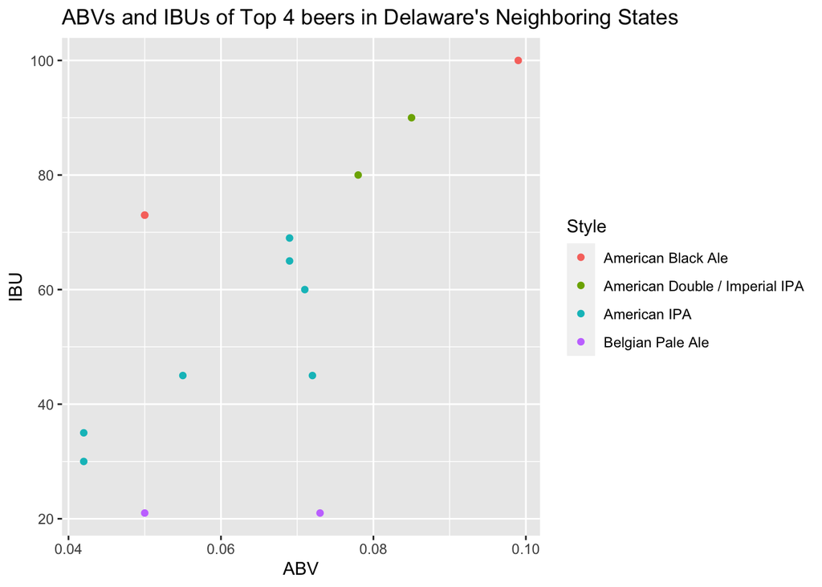

```r
#Print scatter plot of ABV vs IBU by beer style near Delaware
#Recommendation: American IPA w/ ~50-60 IBU and ABV of 7%, Imperial IPA with 80-90 IBU and 8% ABV, Belgian w/ IBU of ~20 and and ABV of 7%..
top4DE %>% ggplot(aes(x = ABV, y = IBU, color = Style)) + geom_point() + ggtitle("ABVs and IBUs of Top 4 beers in Delaware's Neighboring States")
```

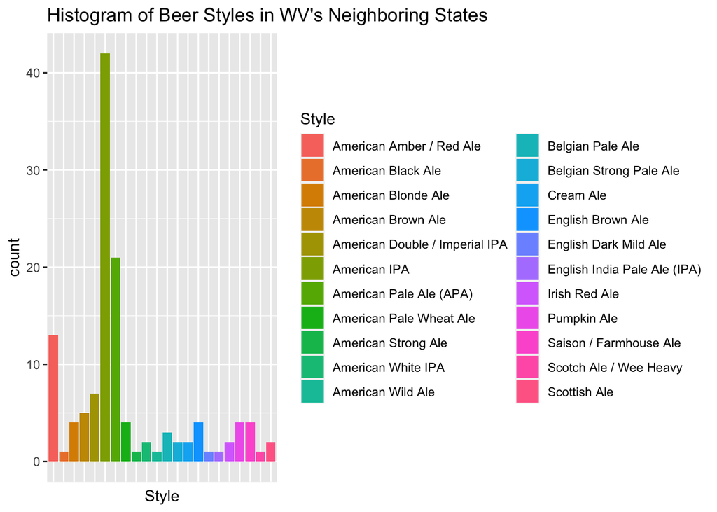

```r
#Create new data frame to hold the beers in neighboring States for West Virginia
beersWV <- brewByState %>% filter(State == " VA" | State == " PA" | State == " OH" | State == " KY")
#Print histogram of the beer styles near West Virginia
beersWV %>% ggplot(aes(x = Style, fill = Style)) + geom_bar(stat = "count") + theme(axis.text.x=element_blank(),
        axis.ticks.x=element_blank()) + ggtitle("Histogram of Beer Styles in WV's Neighboring States")
```

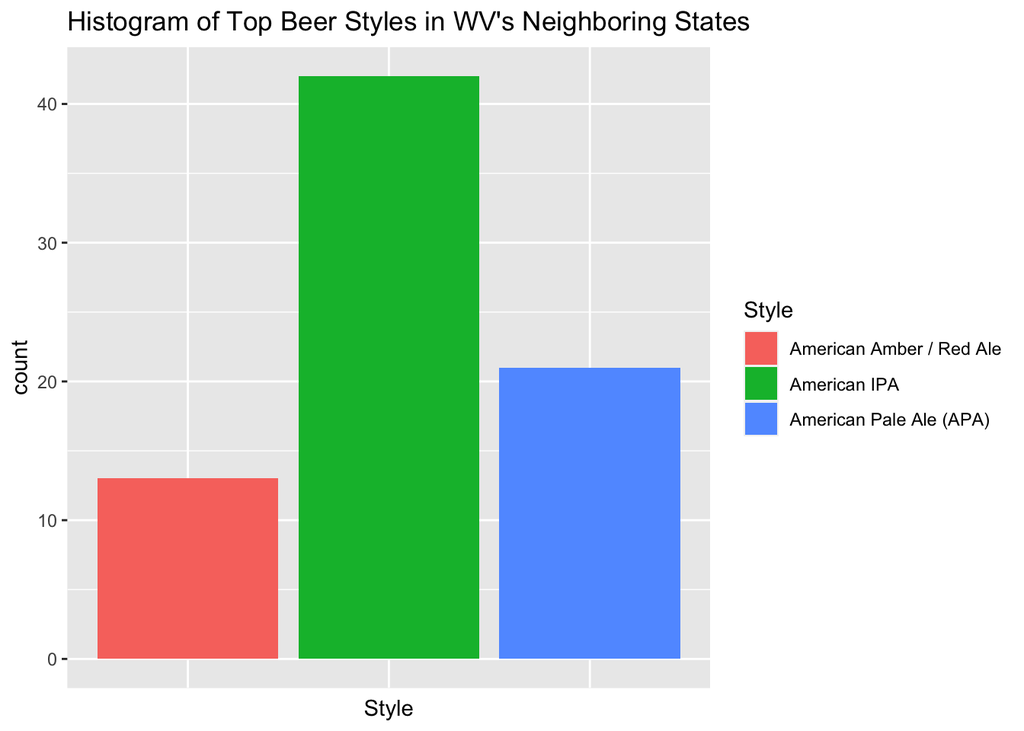

```r
#Top 3 beers near West Virginia: IPAs, APAs, and American Amber / Red Ale
top3WV <- beersWV %>%  filter(Style =="American Amber / Red Ale" | Style == "American IPA" | Style == "American Pale Ale (APA)")
#Print the histogram of the top 3 beer styles
top3WV %>% ggplot(aes(x = Style, fill = Style)) + geom_bar(stat = "count") + theme(axis.text.x=element_blank(),
        axis.ticks.x=element_blank()) + ggtitle("Histogram of Top Beer Styles in WV's Neighboring States")
```

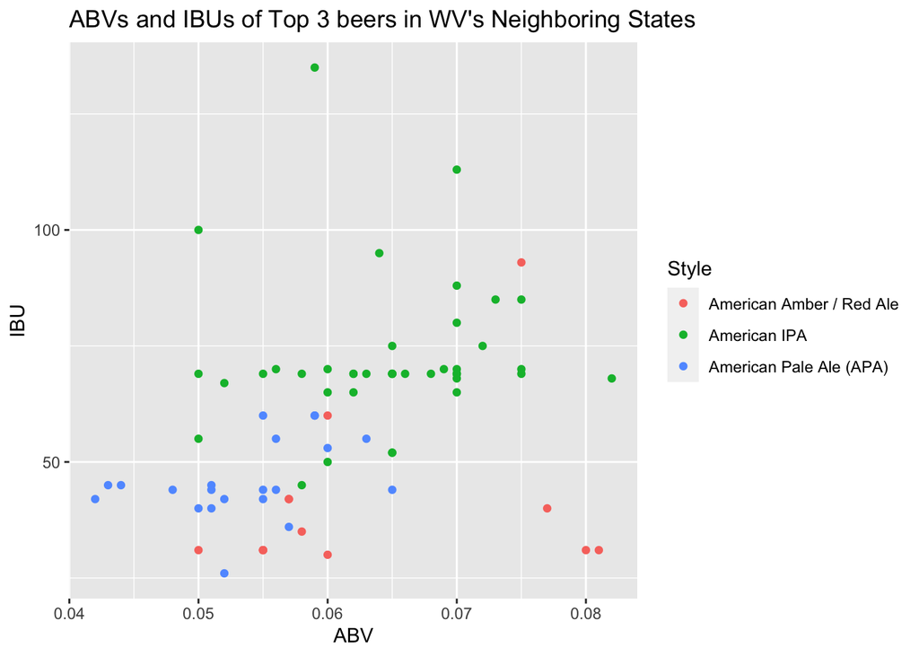

```r
#Print scatter plot of ABV vs IBU by Style for West Virginia
#Recommendation: American IPA of ~70 IBU and ABV of 6-7%, APA of 45 IBU and 5-6% ABV. Red Ale is inconclusive
top3WV %>% ggplot(aes(x = ABV, y = IBU, color = Style)) + geom_point() + ggtitle("ABVs and IBUs of Top 3 beers in WV's Neighboring States")
```